# Homework5-DataVis-ggplot

Saw Sudta

DUE: Thursday, March 25

#### Necessary items:

- **libraries:** tidyverse, ggsci, ggforce, patchwork, Hmisc
- **files:** bloom_df.csv, hw_task2_blank.png

Within RStudio you can directly edit these blocks of code and turn in your homework that way with your code and figures printed.  
I **HIGHLY** recommend getting your code to work in a normal R script then just copy and pasting the final code over to this document

**First: import libraries, set your working directory, and read in bloom_df**

```r
library(tidyverse)
library(ggforce)
library(ggsci)
library(patchwork)
library(Hmisc)
library(ggplot2)

setwd("~/Desktop/Part.3_DataVisualization/1-ggplot")

bloom_df <- read.csv('bloom_df.csv')
```

### bloom_df contents

- **taxa:** genus_species
- **genus**
- **species**
- **logbodysize**
- **trophic_position**
- **reg:** diadromous or non-diadromous

Let’s take a peak and look at the structure

```r
bloom_df[1:5,]
```

```
##                   taxa genus        species logbodysize trophic_position
## 1       Alosa_alabamae Alosa       alabamae    1.707570        0.4313638
## 2          Alosa_alosa Alosa          alosa    1.778151        0.5563025
## 3         Alosa_fallax Alosa         fallax    1.778151        0.5563025
## 4      Alosa_mediocris Alosa      mediocris    1.778151        0.6127839
## 5 Alosa_pseudoharengus Alosa pseudoharengus    1.602060        0.5440680
##          reg
## 1 diadromous
## 2 diadromous
## 3 diadromous
## 4 diadromous
## 5 diadromous
```

```r
str(bloom_df)
```

```
## 'data.frame':    50 obs. of  6 variables:
##  $ taxa            : Factor w/ 50 levels "Alosa_alabamae",..: 1 2 3 4 5 6 7 8 9 10 ...
##  $ genus           : Factor w/ 34 levels "Alosa","Amazonsprattus",..: 1 1 1 1 1 1 2 3 3 3 ...
##  $ species         : Factor w/ 48 levels "aestuaria","alabamae",..: 2 3 19 31 36 39 41 11 13 14 ...
##  $ logbodysize     : num  1.71 1.78 1.78 1.78 1.6 ...
##  $ trophic_position: num  0.431 0.556 0.556 0.613 0.544 ...
##  $ reg             : Factor w/ 2 levels "diadromous","non-diadromous": 1 1 1 1 1 1 2 2 2 2 ...
```

### Graphical tasks

This next tasks are going to ask you to make a series of figures. For each one, I would like you to make all of them *look good*. Change the theme around, change the axis labels, etc. Additionally, each of these will use the **reg** column which has 2 factors. Change the color and/or shape of them both.

### Task 1: Continuous vs. continuous plot

Create two scatterplots of logbodysize vs. trophic_position grouped by reg

##### First plot:

- a 2 trend lines (method = ‘lm’), one for each reg variable

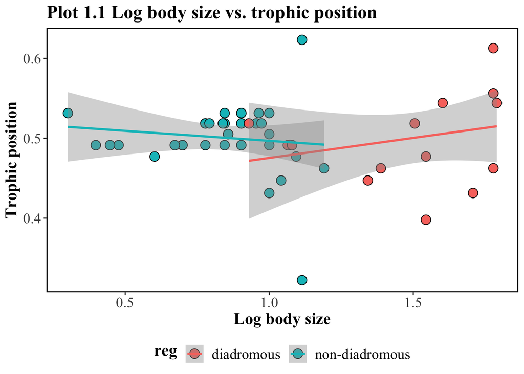

```r
#plot 1.1
ggplot(data=bloom_df,aes(x=logbodysize,y=trophic_position,colour=reg)) + #set x-and y- values
  geom_point(aes(fill=reg),size=4,pch=21,colour='black') + #fill color with reg
  stat_smooth(method = "lm", linetype='solid', size=1) + #fit a trendline using method= 'lm'
  xlab('Log body size') +  #label x-axis
  ylab('Trophic position')+ #label y-axis
  ggtitle('Plot 1.1 Log body size vs. trophic position')+ #add a plot title
  theme_bw() +  #change a plot theme to black and white
  theme(legend.position = 'bottom', #manually control components of the layout
        plot.title = element_text(family = "Times New Roman",  size = 18, colour="black",face = "bold"),
        axis.text = element_text(family = "Times New Roman",size=14),
        axis.title = element_text(family = "Times New Roman",size = 16, colour="black",face = "bold"),
        panel.border = element_rect(size = 1, colour = "black"),
        legend.title = element_text(family = "Times New Roman",size = 16, colour="black",face = "bold",vjust =1),
        legend.text = element_text(family = "Times New Roman",size=14),
        panel.grid.major = element_blank(),
        panel.grid.minor = element_blank())
```

##### Second plot

- a single trend line for the whole model

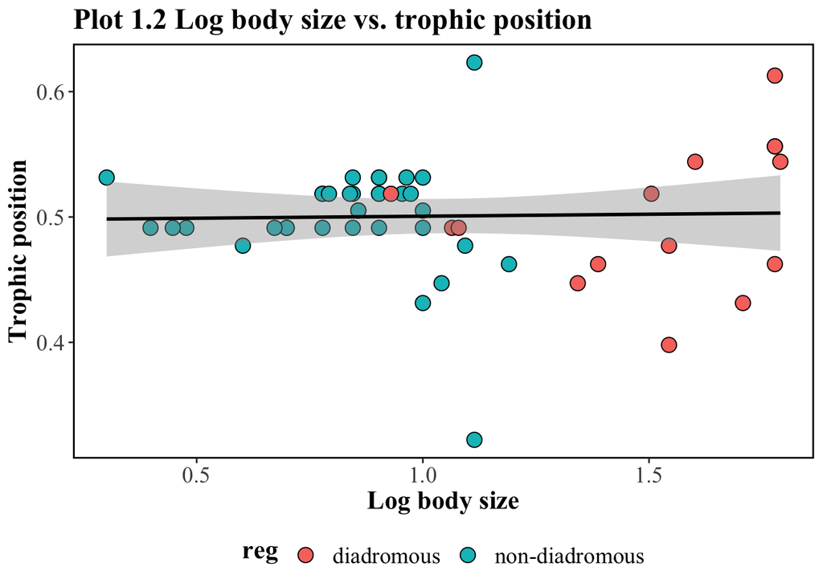

```r
#plot 1.2
ggplot(data=bloom_df,aes(x=logbodysize,y=trophic_position)) + #remove 'color=reg' to grate a single trendline for the whole model
  geom_point(aes(fill=reg),size=4,pch=21,colour='black') + #fill color with reg
  stat_smooth(method = "lm", linetype='solid',color='black', size=1) + #fit a trendline using method= 'lm'
  xlab('Log body size') +  #label x-axis
  ylab('Trophic position')+ #label y-axis
  ggtitle('Plot 1.2 Log body size vs. trophic position')+ #add a plot title
  theme_bw() +  #change a plot theme to black and white
  theme(legend.position = 'bottom', #manually control components of the layout
        plot.title = element_text(family = "Times New Roman",  size = 18, colour="black",face = "bold"),
        axis.text = element_text(family = "Times New Roman",size=14),
        axis.title = element_text(family = "Times New Roman",size = 16, colour="black",face = "bold"),
        panel.border = element_rect(size = 1, colour = "black"),
        legend.title = element_text(family = "Times New Roman",size = 16, colour="black",face = "bold",vjust =1),
        legend.text = element_text(family = "Times New Roman",size=14),
        panel.grid.major = element_blank(),
        panel.grid.minor = element_blank())
```

### Task 2: Continuous vs. categorical

##### The layout will be:

- 2 panels: trophic_position and logbodysize
- x axis: reg
- y axis: value of trophic_position and logbodysize

##### Create 4 plots:

- bar and error bars (mean and 95% conf. int.)
- point and error bars (mean and 95% conf. int.)
- box plots
- raw data + point and error bars (mean and 95% conf. int.)

All these plots should have the same general layout but change the type of plot to visualize the data.

**HINT:** logbodysize and trophic_position need to be turned into long format

##### Example layout:

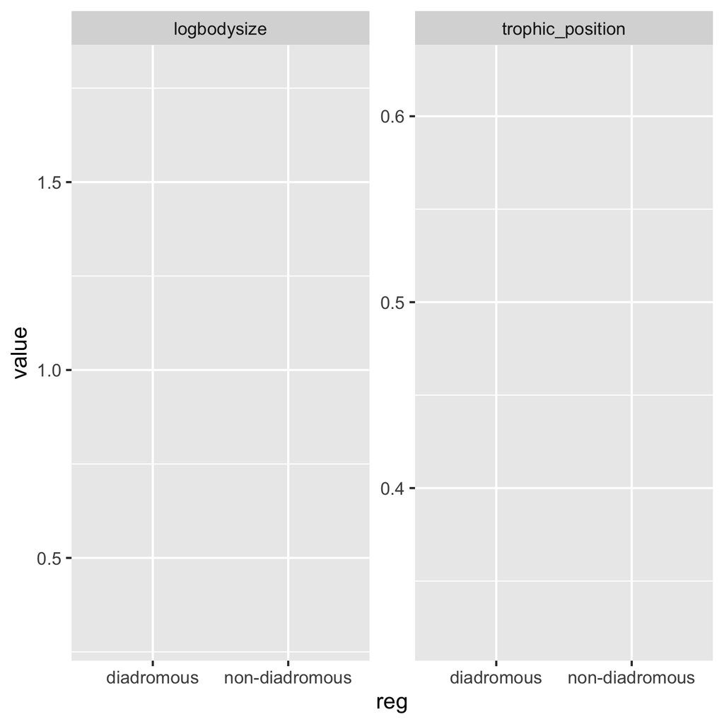

sample layout for task2

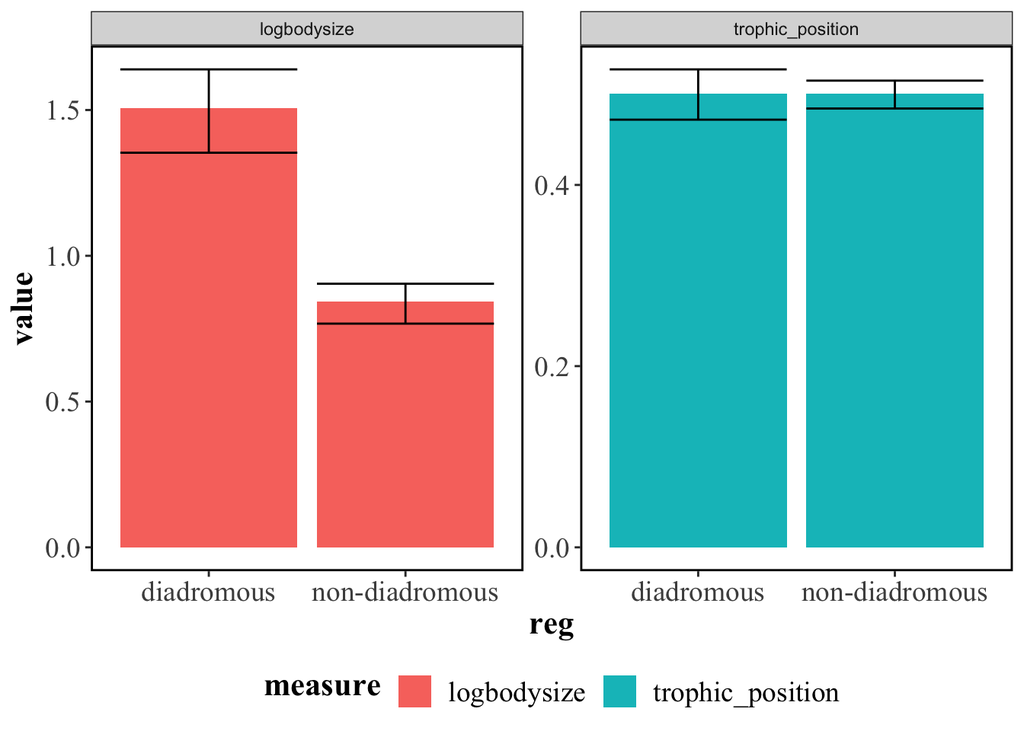

```r
#turning data into a long format
#log body size
body_df <- bloom_df %>% select ('taxa','genus','species','logbodysize','reg')
body_df$measure <- 'logbodysize'
#change column name 'logbodysize' to 'value'
colnames(body_df)[4] <- "value"

#trophic position
trophic_df <- bloom_df %>% select ('taxa','genus','species','trophic_position','reg')
trophic_df$measure <- 'trophic_position'
#change column name 'logbodysize' to 'value'
colnames(trophic_df)[4] <- "value"

#combine body_df with trophic_df to create a long formatted df
long_df <- rbind(body_df,trophic_df)
long_df$measure <- as.factor(long_df$measure)
#plot 2.1
ggplot(data=long_df,aes(x=reg,y=value,fill=measure)) +
  facet_wrap(~measure,nrow=1,scales = 'free') +
  stat_summary(fun = mean, geom = "bar") +
  stat_summary(fun.data = mean_cl_boot, geom = "errorbar",color='black') +
  theme_bw() +  #change a plot theme to black and white
  theme(legend.position = 'bottom', #manually control components of the layout
        plot.title = element_text(family = "Times New Roman",  size = 18, colour="black",face = "bold"),
        axis.text = element_text(family = "Times New Roman",size=14),
        axis.title = element_text(family = "Times New Roman",size = 16, colour="black",face = "bold"),
        panel.border = element_rect(size = 1, colour = "black"),
        legend.title = element_text(family = "Times New Roman",size = 16, colour="black",face = "bold",vjust =1),
        legend.text = element_text(family = "Times New Roman",size=14),
        panel.grid.major = element_blank(),
        panel.grid.minor = element_blank())
```

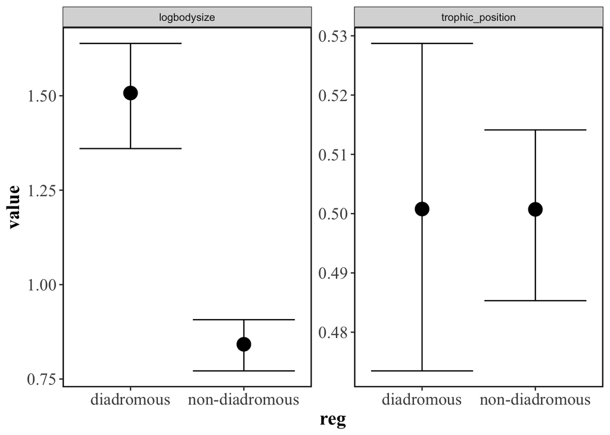

```r
#plot 2.2
ggplot(data=long_df,aes(x=reg,y=value)) +
  facet_wrap(~measure,nrow=1,scales = 'free') +
  stat_summary(fun.data = mean_cl_boot, geom = "errorbar",color='black') +
  stat_summary(fun = mean, geom = "point", size =5) +
  theme_bw() +  #change a plot theme to black and white
  theme(legend.position = 'bottom', #manually control components of the layout
        plot.title = element_text(family = "Times New Roman",  size = 18, colour="black",face = "bold"),
        axis.text = element_text(family = "Times New Roman",size=14),
        axis.title = element_text(family = "Times New Roman",size = 16, colour="black",face = "bold"),
        panel.border = element_rect(size = 1, colour = "black"),
        legend.title = element_text(family = "Times New Roman",size = 16, colour="black",face = "bold",vjust =1),
        legend.text = element_text(family = "Times New Roman",size=14),
        panel.grid.major = element_blank(),
        panel.grid.minor = element_blank())
```

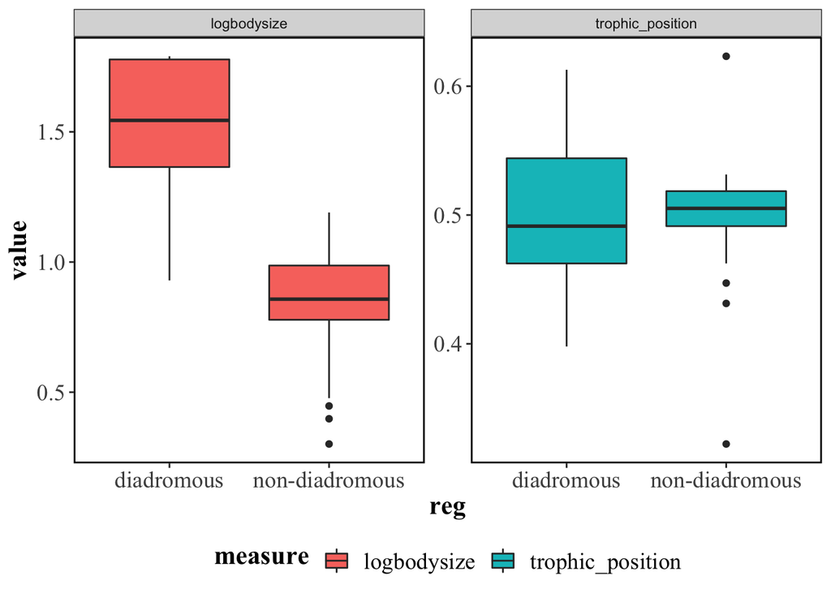

```r
#plot 2.3
ggplot(data=long_df,aes(x=reg,y=value,fill=measure)) +
  facet_wrap(~measure,nrow=1,scales = 'free') +
  geom_boxplot() +
  theme_bw() +  #change a plot theme to black and white
  theme(legend.position = 'bottom', #manually control components of the layout
        plot.title = element_text(family = "Times New Roman",  size = 18, colour="black",face = "bold"),
        axis.text = element_text(family = "Times New Roman",size=14),
        axis.title = element_text(family = "Times New Roman",size = 16, colour="black",face = "bold"),
        panel.border = element_rect(size = 1, colour = "black"),
        legend.title = element_text(family = "Times New Roman",size = 16, colour="black",face = "bold",vjust =1),
        legend.text = element_text(family = "Times New Roman",size=14),
        panel.grid.major = element_blank(),
        panel.grid.minor = element_blank())
```

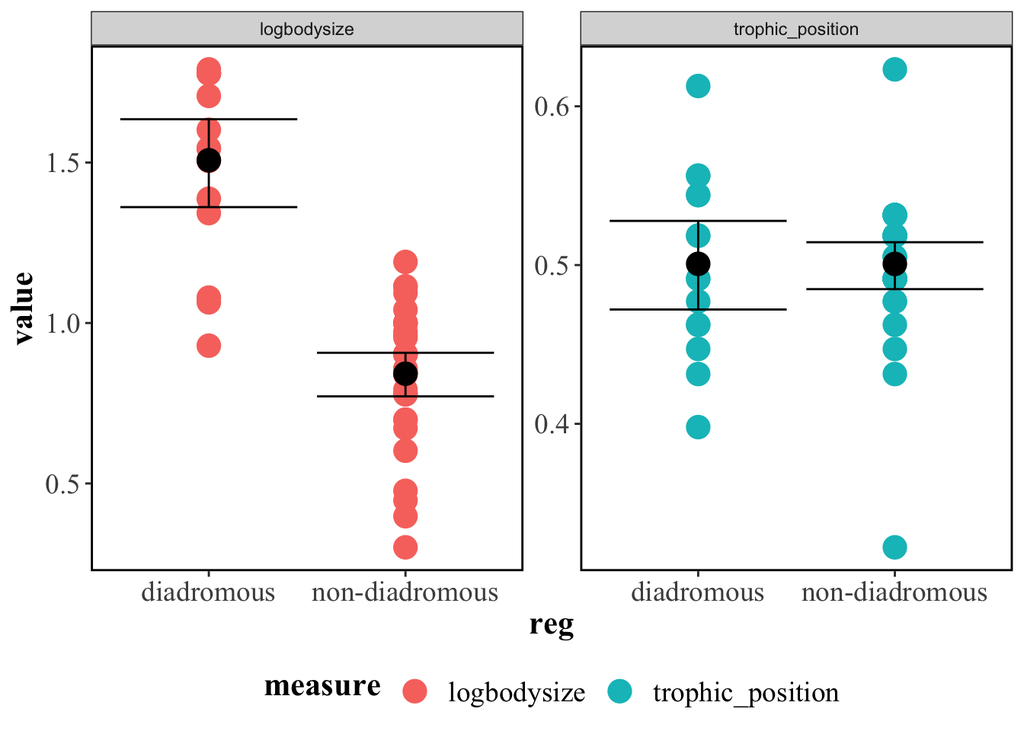

```r
#plot 2.4
ggplot(data=long_df,aes(x=reg,y=value,color=measure)) +
  facet_wrap(~measure,nrow=1,scales = 'free') +
  geom_point(size=5) +
  stat_summary(fun.data = mean_cl_boot, geom = "errorbar",color='black') +
  stat_summary(fun = mean, geom = "point", size=5, color='black') +
  theme_bw() +  #change a plot theme to black and white
  theme(legend.position = 'bottom', #manually control components of the layout
        plot.title = element_text(family = "Times New Roman",  size = 18, colour="black",face = "bold"),
        axis.text = element_text(family = "Times New Roman",size=14),
        axis.title = element_text(family = "Times New Roman",size = 16, colour="black",face = "bold"),
        panel.border = element_rect(size = 1, colour = "black"),
        legend.title = element_text(family = "Times New Roman",size = 16, colour="black",face = "bold",vjust =1),
        legend.text = element_text(family = "Times New Roman",size=14),
        panel.grid.major = element_blank(),
        panel.grid.minor = element_blank())
```

### Task 3: layering your plots

Make any two figures with the bloom_df! Can be something we’ve done or something completely different. Make one TERRIBLE figure and one GREAT figure.

Put them together using *patchwork* or *ggarrange*

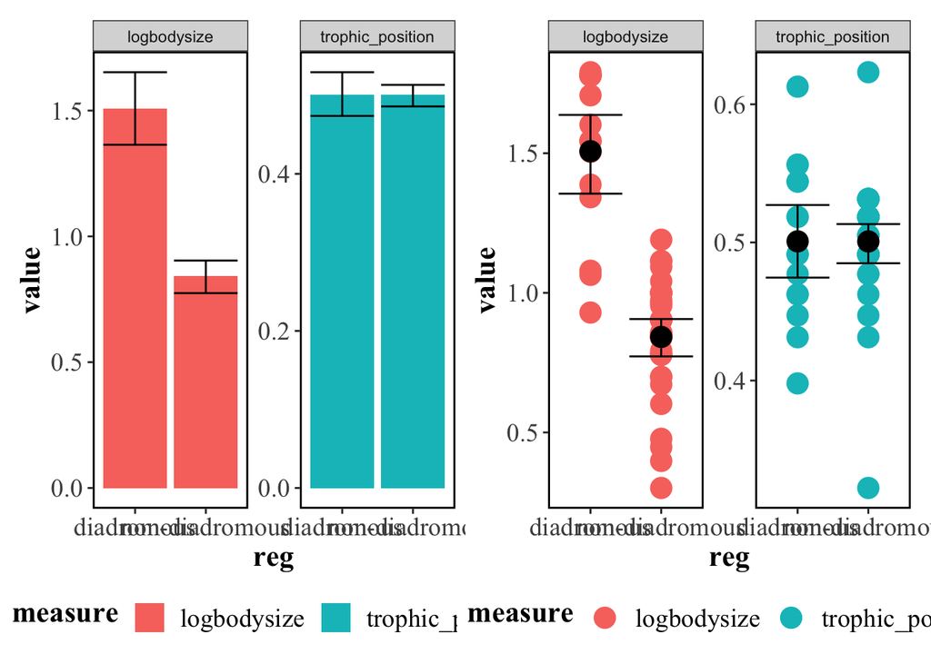

```r
#plot 3
#Task 3. Layering plots
#using patchwork
#I'm using plots previously created on Task 2.
plot21 <- ggplot(data=long_df,aes(x=reg,y=value,fill=measure)) +
  facet_wrap(~measure,nrow=1,scales = 'free') +
  stat_summary(fun = mean, geom = "bar") +
  stat_summary(fun.data = mean_cl_boot, geom = "errorbar",color='black') +
  theme_bw() +  #change a plot theme to black and white
  theme(legend.position = 'bottom', #manually control components of the layout
        plot.title = element_text(family = "Times New Roman",  size = 18, colour="black",face = "bold"),
        axis.text = element_text(family = "Times New Roman",size=14),
        axis.title = element_text(family = "Times New Roman",size = 16, colour="black",face = "bold"),
        panel.border = element_rect(size = 1, colour = "black"),
        legend.title = element_text(family = "Times New Roman",size = 16, colour="black",face = "bold",vjust =1),
        legend.text = element_text(family = "Times New Roman",size=14),
        panel.grid.major = element_blank(),
        panel.grid.minor = element_blank())
plot24 <- ggplot(data=long_df,aes(x=reg,y=value,color=measure)) +
  facet_wrap(~measure,nrow=1,scales = 'free') +
  geom_point(size=5) +
  stat_summary(fun.data = mean_cl_boot, geom = "errorbar",color='black') +
  stat_summary(fun = mean, geom = "point", size=5, color='black') +
  theme_bw() +  #change a plot theme to black and white
  theme(legend.position = 'bottom', #manually control components of the layout
        plot.title = element_text(family = "Times New Roman",  size = 18, colour="black",face = "bold"),
        axis.text = element_text(family = "Times New Roman",size=14),
        axis.title = element_text(family = "Times New Roman",size = 16, colour="black",face = "bold"),
        panel.border = element_rect(size = 1, colour = "black"),
        legend.title = element_text(family = "Times New Roman",size = 16, colour="black",face = "bold",vjust =1),
        legend.text = element_text(family = "Times New Roman",size=14),
        panel.grid.major = element_blank(),
        panel.grid.minor = element_blank())

#Layering plot21 and plot 24
#Plot 3
plot21 +plot24
```